# Soil Color Contrast

D.E. Beaudette

2026-03-03

# 1 Introduction

## 1.1 Perceptual Color Distance

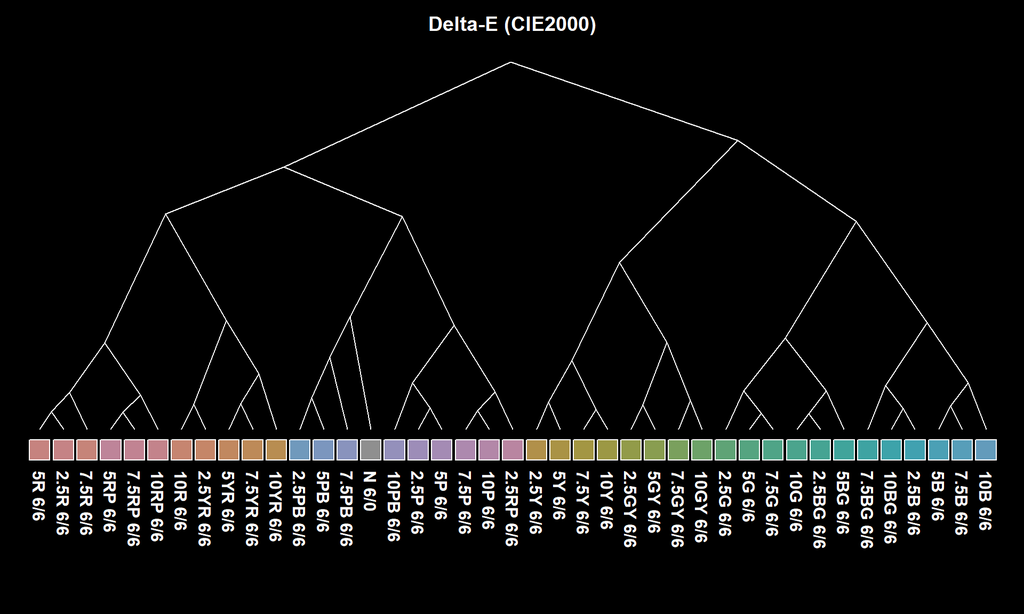

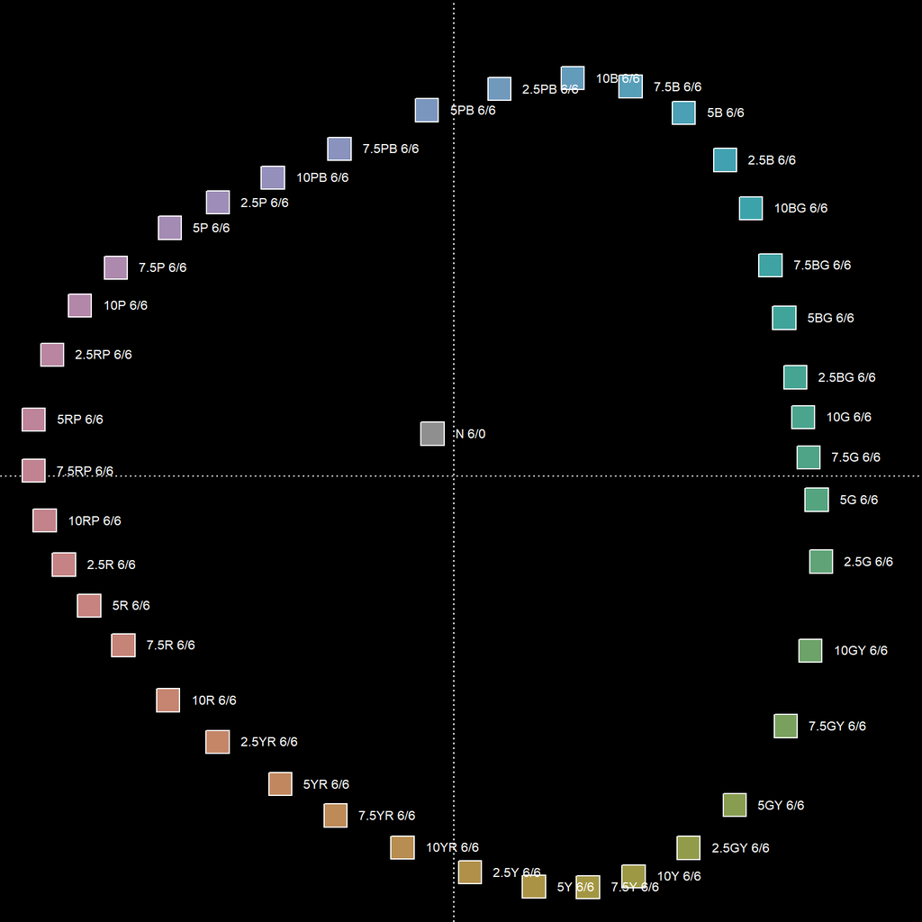

## 1.2 Soil Color Contrast Class

## 1.3 Delta-E

# 2 Applications

## 2.1 Setup

```r
library(aqp)
library(soilDB)
library(farver)
library(cluster)
library(ape)
library(colorspace)
library(latticeExtra)
library(knitr)
library(MASS)
library(vegan)
library(viridisLite)
library(tactile)
```

## 2.2 Core Functions

[Soil Survey Technical Note 2](https://www.nrcs.usda.gov/wps/portal/nrcs/detail/soils/ref/?cid=nrcs142p2_053569)

### 2.2.1 Color Contrast Metrics

Compute several indices of color contrast from 2 vectors of Munsell colors, `m1` and `m2`. Comparisons fully vectorized, e.g. comparisons performed element-wise $m1_i ~\leftrightarrow~ m2_i$ $...$ $m1_n ~\leftrightarrow~ m2_n$.

- $dH$: change in Munsell hue, see *Hue Position* section below
- $dV$: change in Munsell value (absolute value of difference)
- $dC$: change in Munsell chroma (absolute value of difference)
- $\Delta{E_{00}}$: CIE2000 Delta-E [#1](http://zschuessler.github.io/DeltaE/learn/), [#2](https://en.wikipedia.org/wiki/Color_difference#CIEDE2000)
- $cc$: soil color contrast class ([Soil Survey Technical Note 2](https://www.nrcs.usda.gov/wps/portal/nrcs/detail/soils/ref/?cid=nrcs142p2_053569))

Results as a `data.frame`.

```r
# examples
m1 <- c('10YR 6/3', '7.5YR 3/3', '10YR 2/2', '7.5YR 3/4')
m2 <- c('5YR 3/4', '7.5YR 4/4', '2.5YR 2/2', '7.5YR 6/3')

# result is a data.frame
d <- colorContrast(m1, m2)

# check
kable(d, row.names=FALSE)
```

| m1 | m2 | dH | dV | dC | dE00 | cc |
| --- | --- | --- | --- | --- | --- | --- |
| 10YR 6/3 | 5YR 3/4 | 2 | 3 | 1 | 31.286373 | Prominent |
| 7.5YR 3/3 | 7.5YR 4/4 | 0 | 1 | 1 | 9.657423 | Faint |
| 10YR 2/2 | 2.5YR 2/2 | 3 | 0 | 0 | 6.814101 | Faint |
| 7.5YR 3/4 | 7.5YR 6/3 | 0 | 3 | 1 | 30.261643 | Distinct |

Results summarized in a figure.

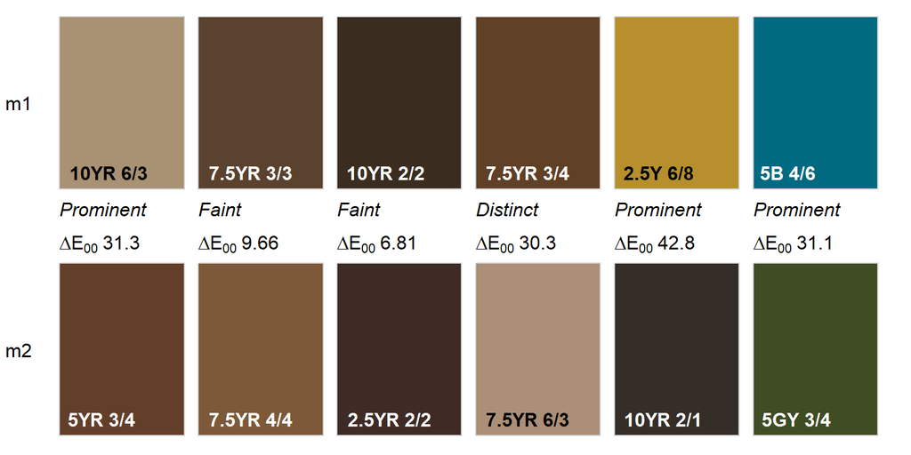

```r
# more examples
m1 <- c('10YR 6/3', '7.5YR 3/3', '10YR 2/2', '7.5YR 3/4', '2.5Y 6/8', '5B 4/6')
m2 <- c('5YR 3/4', '7.5YR 4/4', '2.5YR 2/2', '7.5YR 6/3', '10YR 2/1', '5GY 3/4')

# graphical comparison
colorContrastPlot(m1, m2)
```

Simulated redoximorphic feature colors, contrast classes and $\Delta{E_{00}}$.

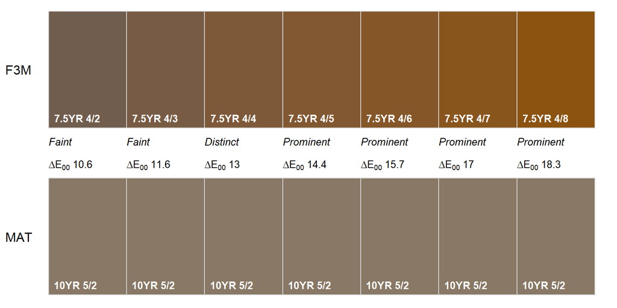

```r
m1 <- paste0('7.5YR 4/', 2:8)
m2 <- rep('10YR 5/2', times=length(m1))
colorContrastPlot(m1, m2, labels = c('F3M', 'MAT'), d.cex = 0.8, col.cex = 0.8)
```

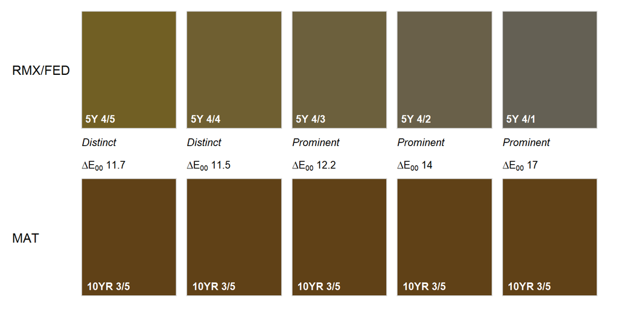

```r
m1 <- paste0('5Y 4/', 5:1)
m2 <- rep('10YR 3/5', times=length(m1))
colorContrastPlot(m1, m2, labels = c('RMX/FED', 'MAT'), d.cex = 0.8, col.cex = 0.8)
```

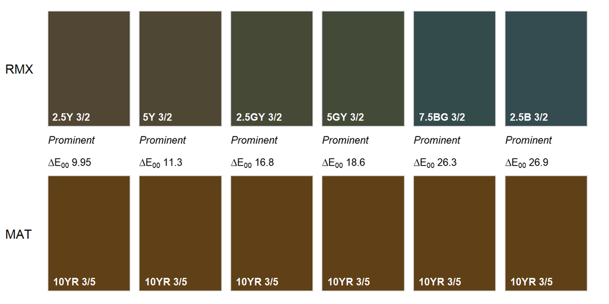

```r
m1 <- c('2.5Y 3/2', '5Y 3/2', '2.5GY 3/2', '5GY 3/2', '7.5BG 3/2', '2.5B 3/2')
m2 <- rep('10YR 3/5', times=length(m1))
colorContrastPlot(m1, m2, labels = c('RMX', 'MAT'), d.cex = 0.8, col.cex = 0.8)
```